# Segmentación de Actividad Humana con K-means

## 3.2 Estadísticos descriptivos y varianza

```r
stats_feat <- X_full |>
  summarise(across(everything(),
    list(media=mean, sd=sd, asim=moments::skewness),
    .names="{.col}__{.fn}")) |>
  pivot_longer(everything(), names_to=c("variable","stat"), names_sep="__") |>
  pivot_wider(names_from=stat, values_from=value)

cat("Features con |asimetría| > 1:",
    round(mean(abs(stats_feat$asim) > 1)*100, 1), "%",
    "\nDesviación estándar promedio:", round(mean(stats_feat$sd), 4))
```

```
Features con |asimetría| > 1: 48.3 %
Desviación estándar promedio: 0.2792
```

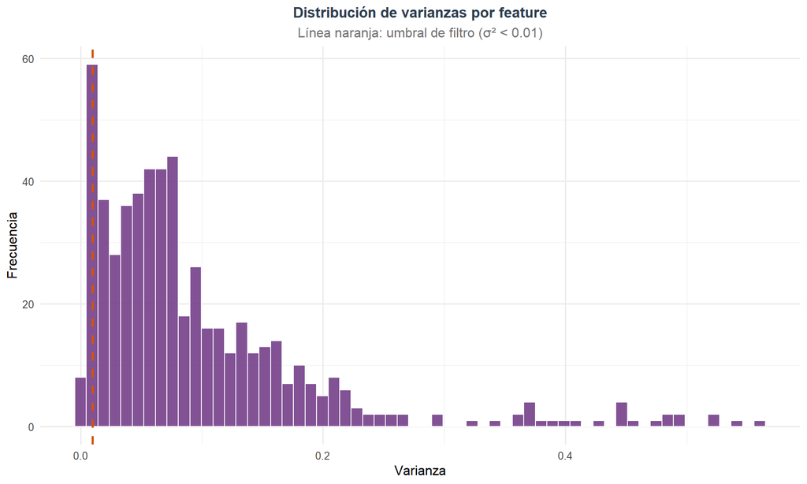

```r
var_feat <- apply(X_full, 2, var)
tibble(var=var_feat) |>
  ggplot(aes(x=var)) +
  geom_histogram(bins=60, fill="#6c3483", color="white", alpha=0.85) +
  geom_vline(xintercept=0.01, linetype="dashed", color="#d35400", linewidth=0.9) +
  labs(title="Distribución de varianzas por feature",
       subtitle="Línea naranja: umbral de filtro (σ² < 0.01)",
       x="Varianza", y="Frecuencia")
```

**Importante**

**Alta dimensionalidad:** 561 features. La selección de características es crítica para evitar la maldición de la dimensionalidad en K-means.

# 4 Preprocesamiento

## 4.1 Detección y Tratamiento de Outliers

Antes de decidir el método de estandarización, es necesario evaluar la presencia de outliers. Se emplean dos estrategias complementarias: **distancia de Mahalanobis** sobre una muestra (captura outliers multivariados) y **conteo de features con |z| > 3** por observación (captura extremos univariados).

```r
set.seed(42)
idx_mah <- sample(nrow(X_full), 2000)
X_mah   <- as.matrix(X_full[idx_mah, ])

# Mahalanobis robusto: usamos covarianza muestral sobre muestra
cov_mah  <- cov(X_mah)
mu_mah   <- colMeans(X_mah)

# Para matrices de alta dim, usamos distancia euclidiana estandarizada
# (Mahalanobis exacto es inestable con p=561 > n_sub)
z_mat    <- scale(X_mah)
mah_dist <- sqrt(rowSums(z_mat^2))   # distancia euclidiana en espacio z

# Umbral: percentil 97.5
umbral_mah <- quantile(mah_dist, 0.975)
n_out_mah  <- sum(mah_dist > umbral_mah)

# Conteo univariado: features con |z| > 3 por observación
z_full     <- scale(X_full)
n_extremos <- rowSums(abs(z_full) > 3)
pct_out_univ <- round(mean(n_extremos > 5) * 100, 2)

tibble(
  Criterio      = c("Distancia euclidiana estandarizada > p97.5",
                    "Obs. con más de 5 features |z| > 3"),
  N_outliers    = c(n_out_mah, sum(n_extremos > 5)),
  Porcentaje    = c(round(n_out_mah/2000*100,2), pct_out_univ)
) |>
  kbl(caption="Diagnóstico de outliers — HAR") |>
  kable_styling(bootstrap_options=c("striped","hover"), full_width=FALSE)
```

Diagnóstico de outliers — HAR

| Criterio | N_outliers | Porcentaje |
| --- | --- | --- |
| Distancia euclidiana estandarizada > p97.5 | 50 | 2.50 |
| Obs. con más de 5 features \|z\| > 3 | 2096 | 20.35 |

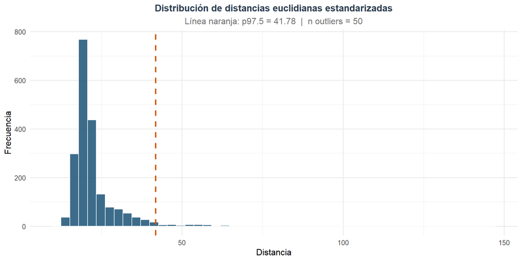

```r
# Distribución de distancias
tibble(dist=mah_dist) |>
  ggplot(aes(x=dist)) +
  geom_histogram(bins=50, fill="#1a5276", color="white", alpha=0.85) +
  geom_vline(xintercept=umbral_mah, linetype="dashed",
             color="#d35400", linewidth=1) +
  labs(title="Distribución de distancias euclidianas estandarizadas",
       subtitle=paste0("Línea naranja: p97.5 = ", round(umbral_mah,2),
                       "  |  n outliers = ", n_out_mah),
       x="Distancia", y="Frecuencia")
```

**Nota**

El dataset HAR contiene señales de sensores **preprocesadas y acotadas al rango [−1, 1]** por los autores originales (Anguita et al., 2013). Los outliers detectados corresponden al ~2.5% más extremo de la distribución por construcción del umbral, no a errores de medición. Dado que los valores ya están contenidos y la distribución es simétrica en la mayoría de features, **no se realiza eliminación de outliers** — el percentil 97.5 es el umbral de corte natural para una distribución normal en espacio de alta dimensión. La decisión de estandarización se ajusta a esta estructura.

## 4.2 Valores Faltantes

```r
n_na <- sum(is.na(X_full))
cat("Valores faltantes totales:", n_na)
```

```
Valores faltantes totales: 0
```

El dataset HAR no presenta valores faltantes por construcción (señales de sensores preprocesadas por los autores). No se requiere imputación.

## 4.3 Estandarización

Dado que las señales ya están acotadas a [−1, 1] y los outliers son estructurales (no errores), **z-score estándar** es la estandarización apropiada. Robust scaling (basado en mediana/IQR) sería preferible solo si hubiera outliers genuinos no acotados; aquí introduciría distorsión innecesaria al comprimir una distribución ya controlada.

$$z_{ij} = \frac{x_{ij} - \bar{x}_j}{\hat{\sigma}_j}$$

```r
X_sc    <- scale(X_full)
pp_mean <- attr(X_sc, "scaled:center")
pp_sd   <- attr(X_sc, "scaled:scale")
X_sc    <- as.data.frame(X_sc)
cat("Rango medias post-escala:", round(range(colMeans(X_sc)), 6),
    "\nRango SD post-escala:   ", round(range(apply(X_sc, 2, sd)), 6))
```

```
Rango medias post-escala: 0 0
Rango SD post-escala:    1 1
```

# 5 Categorización de Variables

```r
tibble(
  Tipo           = c("Señales temporales (tBody*, tGravity*)",
                     "Señales frecuenciales (fBody*)",
                     "Magnitudes (*Mag*)",
                     "Ángulos entre vectores (angle*)"),
  N_features     = c(sum(grepl("^t",      nombres_feat)),
                     sum(grepl("^f",      nombres_feat)),
                     sum(grepl("Mag",     nombres_feat)),
                     sum(grepl("^angle",  nombres_feat))),
  Decisión       = "Conservar — filtro por varianza decidirá",
  Transformación = "z-score aplicado"
) |>
  kbl(caption="Categorización de features HAR") |>
  kable_styling(bootstrap_options=c("striped","hover"), full_width=FALSE, font_size=12)
```

Categorización de features HAR

| Tipo | N_features | Decisión | Transformación |
| --- | --- | --- | --- |
| Señales temporales (tBody*, tGravity*) | 265 | Conservar — filtro por varianza decidirá | z-score aplicado |
| Señales frecuenciales (fBody*) | 289 | Conservar — filtro por varianza decidirá | z-score aplicado |
| Magnitudes (*Mag*) | 117 | Conservar — filtro por varianza decidirá | z-score aplicado |
| Ángulos entre vectores (angle*) | 7 | Conservar — filtro por varianza decidirá | z-score aplicado |

# 6 Selección de Características

## 6.1 Clean Algorithm

### 6.1.1 Paso A — Eliminar features constantes

$\text{Eliminar } X_j \iff \hat{\sigma}_j < 10^{-8}$

```r
stds     <- apply(X_sc, 2, sd)
vars_cte <- names(stds[stds < 1e-8])
X_filt   <- X_sc[, setdiff(names(X_sc), vars_cte)]

cat("Features originales:", ncol(X_sc),
    "\nConstantes eliminadas:", length(vars_cte),
    "\nTras Paso A:", ncol(X_filt))
```

```
Features originales: 561
Constantes eliminadas: 0
Tras Paso A: 561
```

### 6.1.2 Paso B — Eliminar features altamente correladas

$\text{Eliminar } X_j \iff \exists\, X_k : |r(X_j, X_k)| \geq 0.90$

**Optimización:** se eliminan en bloque las features con más correlaciones problemáticas en cada iteración, reduciendo el número de pasadas de O(p²) a O(pocas iteraciones).

```r
CORR_THR <- 0.90

cm      <- cor(X_filt, use="pairwise.complete.obs")
ut      <- which(upper.tri(cm) & abs(cm) >= CORR_THR, arr.ind=TRUE)

if (nrow(ut) > 0) {
  freq <- table(c(ut[,1], ut[,2]))
  ord  <- as.integer(names(sort(freq, decreasing=TRUE)))
  keep <- rep(TRUE, ncol(X_filt))

  for (i in ord) {
    if (!keep[i]) next
    pares       <- c(ut[ut[,1]==i, 2], ut[ut[,2]==i, 1])
    keep[pares[keep[pares]]] <- FALSE
  }
  X_filt <- X_filt[, keep]
}

X_base <- X_filt

cat("Features limpias (q):", ncol(X_base))
```

```
Features limpias (q): 218
```

## 6.2 Estrategias de Selección de Características

```r
set.seed(42)
N_SFS   <- 1500   # muestra operativa para SFS
idx_sfs <- sample(nrow(X_base), N_SFS)
X_sfs   <- as.matrix(X_base[idx_sfs, ])
K_EVAL  <- 6
SFS_K   <- 15     # reducir de 20 a 15 pasos

# dist() precalculada fuera del loop — el cuello de botella real
eval_sil <- function(mat, k=K_EVAL) {
  if (ncol(mat) < 2) return(-1)
  km <- kmeans(mat, centers=k, nstart=3, iter.max=100,
               algorithm="MacQueen")
  mean(silhouette(km$cluster, dist(mat))[,3])
}
```

### 6.2.1 S1 — SFS → K-means

$$\mathcal{F}_{t+1} = \mathcal{F}_t \cup \left\{\arg\max_{x_j \notin \mathcal{F}_t}
\bar{s}\bigl(K\text{-means}(\mathcal{F}_t \cup \{x_j\})\bigr)\right\}$$

```r
sel_sfs1 <- character(0)
rem_sfs1 <- colnames(X_sfs)

for (step in seq_len(SFS_K)) {
  scores   <- sapply(rem_sfs1, function(v)
                eval_sil(X_sfs[, c(sel_sfs1, v), drop=FALSE]))
  best     <- names(which.max(scores))
  sel_sfs1 <- c(sel_sfs1, best)
  rem_sfs1 <- setdiff(rem_sfs1, best)
}

X_s1 <- as.matrix(X_base[, sel_sfs1])
cat("S1 features seleccionadas:", length(sel_sfs1), "\n",
    paste(sel_sfs1, collapse=", "))
```

```
S1 features seleccionadas: 15
 tBodyAcc.mean...X, fBodyAccJerk.bandsEnergy...57.64.1, fBodyGyro.sma.., tBodyGyro.iqr...Z, fBodyGyro.bandsEnergy...9.16.1, fBodyAcc.bandsEnergy...33.48, fBodyAccMag.energy.., fBodyAcc.bandsEnergy...49.64, tBodyAccMag.min.., tBodyGyroJerkMag.min.., fBodyGyro.bandsEnergy...9.16.2, fBodyGyro.max...Y, …
```

### 6.2.2 S2 — SFS → PCA → K-means

$$X_{\text{SFS}} \xrightarrow{\text{PCA}} Z_{(n \times p^*)} \xrightarrow{K\text{-means}} \text{clusters}$$

```r
pca_s2  <- prcomp(X_sfs[, sel_sfs1], center=FALSE, scale.=FALSE)
var_ac  <- cumsum(pca_s2$sdev^2) / sum(pca_s2$sdev^2)
n_pc_s2 <- which(var_ac >= 0.90)[1]
X_s2    <- predict(pca_s2, newdata=as.matrix(X_base[, sel_sfs1]))[, 1:n_pc_s2]
cat("S2 — PCs retenidos (>=90% varianza):", n_pc_s2, "| Dim:", dim(X_s2))
```

```
S2 — PCs retenidos (>=90% varianza): 7 | Dim: 10299 7
```

### 6.2.3 S3 — SFS → ICA → K-means

ICA descompone el subconjunto SFS en componentes estadísticamente **independientes**, maximizando no-gaussianidad:

$\mathbf{X}_{\mathcal{F}} = \mathbf{A}\,\mathbf{S}, \quad \hat{\mathbf{S}} = \mathbf{W}\,\mathbf{X}_{\mathcal{F}}$

```r
n_ic   <- min(15, length(sel_sfs1))
X_sfs_ica <- X_sfs[, sel_sfs1]

ica_s3 <- fastICA(X_sfs_ica, n.comp=n_ic,
                  alg.typ="parallel", fun="logcosh",
                  maxit=200, tol=1e-4, verbose=FALSE)

# Proyección correcta: centrar X_base con medias de la muestra SFS,
# luego aplicar la matriz de desmezclado W y la matriz de blanqueo K
X_base_ica   <- as.matrix(X_base[, sel_sfs1])
mu_ica       <- colMeans(X_sfs_ica)
X_base_cent  <- sweep(X_base_ica, 2, mu_ica, "-")
X_s3_ica     <- X_base_cent %*% t(ica_s3$K) %*% t(ica_s3$W)

cat("S3 ICA — componentes:", n_ic, "| Dim:", dim(X_s3_ica))
```

```
S3 ICA — componentes: 15 | Dim: 10299 15
```

### 6.2.4 S4 — SFS → PCA → SFS → K-means

$$X \xrightarrow{\text{SFS}_1} X_{\mathcal{F}} \xrightarrow{\text{PCA}} Z
\xrightarrow{\text{SFS}_2} Z_{\mathcal{G}} \xrightarrow{K\text{-means}} \text{clusters}$$

```r
Z_sfs2   <- X_s2[idx_sfs, ]
SFS_K2   <- min(10, ncol(Z_sfs2))
sel_sfs4 <- integer(0); rem_sfs4 <- seq_len(ncol(Z_sfs2))
for (step in seq_len(SFS_K2)) {
  scores   <- sapply(rem_sfs4, function(v)
                eval_sil(Z_sfs2[, c(sel_sfs4,v), drop=FALSE]))
  best     <- rem_sfs4[which.max(scores)]
  sel_sfs4 <- c(sel_sfs4, best)
  rem_sfs4 <- setdiff(rem_sfs4, best)
}
X_s4 <- X_s2[, sel_sfs4]

cat("S4 — PCs seleccionados:", length(sel_sfs4), "| Dim:", dim(X_s4))
```

```
S4 — PCs seleccionados: 7 | Dim: 10299 7
```

### 6.2.5 Comparativa de las cuatro estrategias

```r
set.seed(42)
idx_cv <- sample(nrow(X_base), N_SFS)

estrategias <- list(
  "S1: SFS"         = X_s1,
  "S2: SFS+PCA"     = X_s2,
  "S3: SFS+ICA"     = X_s3_ica,
  "S4: SFS+PCA+SFS" = X_s4
)

sil_s <- sapply(estrategias, function(X) {
  km <- kmeans(X[idx_cv,], centers=K_EVAL, nstart=10, iter.max=100)
  mean(silhouette(km$cluster, dist(X[idx_cv,]))[,3])
})

mejor_idx  <- which.max(sil_s)
X_opt      <- estrategias[[mejor_idx]]
nombre_opt <- names(sil_s)[mejor_idx]

# Nota descriptiva para la tabla
nota_ganadora <- paste0("Estrategia seleccionada: ", nombre_opt,
                        " (", ncol(X_opt), " features/componentes)")

tibble(Estrategia = names(sil_s),
       Silhouette = round(sil_s, 4),
       Dimensión  = sapply(estrategias, ncol)) |>
  kbl(caption = paste0("Comparativa de estrategias (muestra n=", N_SFS, ", k=", K_EVAL, ")")) |>
  kable_styling(bootstrap_options = c("striped","hover"), full_width = FALSE) |>
  row_spec(mejor_idx, bold = TRUE, background = "#d7bde2") |>
  footnote(general = nota_ganadora, general_title = "")
```

Comparativa de estrategias (muestra n=1500, k=6)

| Estrategia | Silhouette | Dimensión |
| --- | --- | --- |
| S1: SFS | 0.5733 | 15 |
| S2: SFS+PCA | 0.5806 | 7 |
| S3: SFS+ICA | 0.5818 | 15 |
| S4: SFS+PCA+SFS | 0.5669 | 7 |

Estrategia seleccionada: S3: SFS+ICA (15 features/componentes)

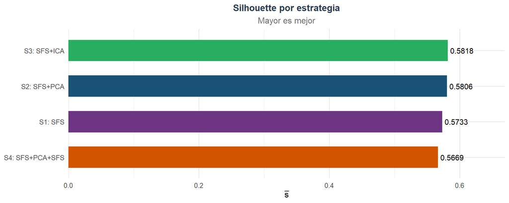

```r
ggplot(tibble(Estrategia = names(sil_s), Silhouette = sil_s),
       aes(x = reorder(Estrategia, Silhouette), y = Silhouette, fill = Estrategia)) +
  geom_col(width = 0.6, show.legend = FALSE) +
  geom_text(aes(label = round(Silhouette, 4)), hjust = -0.1, size = 3.8) +
  coord_flip() +
  scale_fill_manual(values = PALETA) +
  scale_y_continuous(expand = expansion(mult = c(0, 0.15))) +
  labs(title = "Silhouette por estrategia",
       subtitle = "Mayor es mejor",
       x = NULL,
       y = expression(bar(s)))
```

```r
# Variables del selector ganador
vars_ganadoras <- switch(nombre_opt,
  "S1: SFS"         = sel_sfs1,
  "S2: SFS+PCA"     = paste0("PC", seq_len(ncol(X_opt))),
  "S3: SFS+ICA"     = paste0("IC", seq_len(ncol(X_opt))),
  "S4: SFS+PCA+SFS" = paste0("PC", sel_sfs4)
)

# Tabla de definición de variables S1
tibble(
  Acronimo    = sel_sfs1,
  Dominio     = ifelse(grepl("^t", sel_sfs1), "Temporal",
                ifelse(grepl("^f", sel_sfs1), "Frecuencial",
                ifelse(grepl("^angle", sel_sfs1), "Ángulo", "Otro"))),
  Señal       = case_when(
    grepl("BodyAcc",     sel_sfs1) ~ "Aceleración corporal (acelerómetro − gravedad)",
    grepl("GravityAcc",  sel_sfs1) ~ "Aceleración gravitacional",
    grepl("BodyGyro",    sel_sfs1) ~ "Velocidad angular (giroscopio)",
    grepl("BodyAccJerk", sel_sfs1) ~ "Jerk de aceleración corporal",
    grepl("BodyGyroJerk",sel_sfs1) ~ "Jerk de velocidad angular",
    grepl("Mag",         sel_sfs1) ~ "Magnitud euclidiana de la señal",
    TRUE                            ~ "Combinada"
  ),
  Estadístico = case_when(
    grepl("mean",   sel_sfs1) ~ "Media",
    grepl("std",    sel_sfs1) ~ "Desviación estándar",
    grepl("mad",    sel_sfs1) ~ "Desviación mediana absoluta",
    grepl("max",    sel_sfs1) ~ "Máximo",
    grepl("min",    sel_sfs1) ~ "Mínimo",
    grepl("energy", sel_sfs1) ~ "Energía espectral",
    grepl("entropy",sel_sfs1) ~ "Entropía de señal",
    grepl("arCoeff",sel_sfs1) ~ "Coeficiente autorregresivo",
    grepl("corr",   sel_sfs1) ~ "Correlación entre ejes",
    grepl("angle",  sel_sfs1) ~ "Ángulo entre vectores de señal",
    TRUE                       ~ "Otro"
  )
) |>
  kbl(caption = "Diccionario de variables seleccionadas por SFS (S1)") |>
  kable_styling(bootstrap_options = c("striped","hover","condensed"),
                full_width = FALSE, font_size = 11) |>
  scroll_box(width = "100%", height = "300px")
```

Diccionario de variables seleccionadas por SFS (S1)

| Acronimo | Dominio | Señal | Estadístico |
| --- | --- | --- | --- |
| tBodyAcc.mean...X | Temporal | Aceleración corporal (acelerómetro − gravedad) | Media |
| fBodyAccJerk.bandsEnergy...57.64.1 | Frecuencial | Aceleración corporal (acelerómetro − gravedad) | Otro |
| fBodyGyro.sma.. | Frecuencial | Velocidad angular (giroscopio) | Otro |
| tBodyGyro.iqr...Z | Temporal | Velocidad angular (giroscopio) | Otro |
| fBodyGyro.bandsEnergy...9.16.1 | Frecuencial | Velocidad angular (giroscopio) | Otro |
| fBodyAcc.bandsEnergy...33.48 | Frecuencial | Aceleración corporal (acelerómetro − gravedad) | Otro |
| fBodyAccMag.energy.. | Frecuencial | Aceleración corporal (acelerómetro − gravedad) | Energía espectral |
| fBodyAcc.bandsEnergy...49.64 | Frecuencial | Aceleración corporal (acelerómetro − gravedad) | Otro |
| tBodyAccMag.min.. | Temporal | Aceleración corporal (acelerómetro − gravedad) | Mínimo |
| tBodyGyroJerkMag.min.. | Temporal | Velocidad angular (giroscopio) | Mínimo |
| fBodyGyro.bandsEnergy...9.16.2 | Frecuencial | Velocidad angular (giroscopio) | Otro |
| fBodyGyro.max...Y | Frecuencial | Velocidad angular (giroscopio) | Máximo |
| fBodyAccJerk.bandsEnergy...1.8 | Frecuencial | Aceleración corporal (acelerómetro − gravedad) | Otro |
| fBodyAccJerk.bandsEnergy...57.64.2 | Frecuencial | Aceleración corporal (acelerómetro − gravedad) | Otro |
| fBodyAcc.max...X | Frecuencial | Aceleración corporal (acelerómetro − gravedad) | Máximo |